# inference_a

[figure not shown]

[figure not shown]

Statistical Inference I

Prof. Saulo Chaves

Graduate Program in Genetics and Plant Breeding

LGN 5822 - Statistical Genetics I: Foundations

## Summary

1. Probability
2. Random variables
   - Discrete
   - Continuous
   - Parameters and estimates
     - Measures of central tendency
     - Measures of dispersion
3. Exploratory Data Analysis (EDA)

# Probability

## Probability

**Deterministic experiment**

A process that yields the same outcome every time it is repeated under identical conditions, allowing for predictable results

- 2 + 2 = 4
- Boiling water at 100$^\circ$C
- Physical laws

**Non-deterministic (random) experiment**

a process that generates different responses in each repetition, in spite of identical controlled conditions

- Rolling of a die
- Toss of a coin
- Selection of a genotype

## Probability

- Sample space: The set, $S$, of all possible outcomes of a particular experiment
- Event: any collection of possible outcomes $\left(E_1, E_2, ... \right)$ of an experiment, that is, any subset of $S$

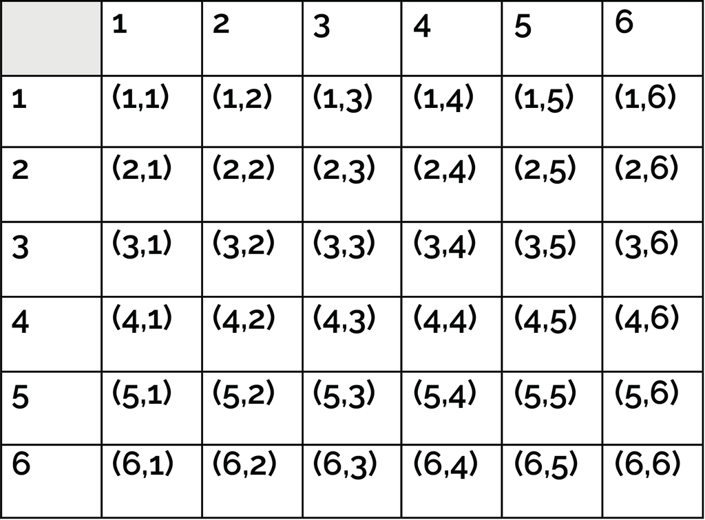

[University of Illinois Urbana-Champaign](https://discovery.cs.illinois.edu/learn/Simulation-and-Distributions/Sample-Space/)

## Probability

**Probability**

A number associated to each member of a set of events obtained after a random experiment. This number must satisfy three mathematical axioms:

$$\Pr(S) = 1$$

$$0 \leq \Pr\left(E_1\right) \leq 1$$

$$\mbox{If } E_1 \cap E_2 = \emptyset \mbox{ then } \Pr\left(E_1 \cup E_2\right) = \Pr\left(E_1 \right) + \Pr \left(E_2\right)$$

**Intuitive concept of probability**: frequency of an event after $n$ repetitions of an experiment

## Probability

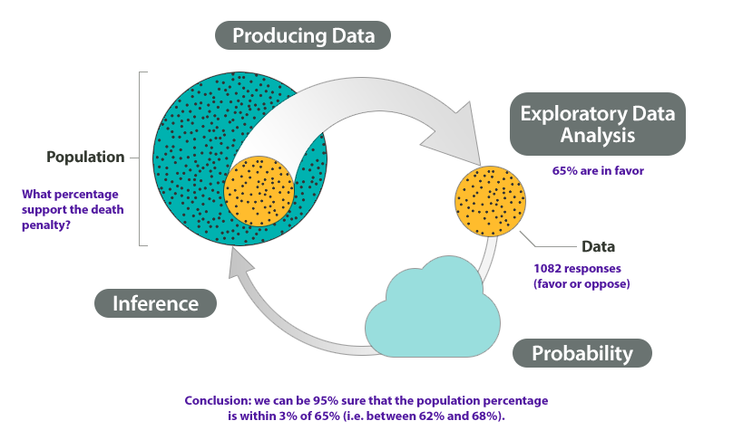

[Lumen](https://courses.lumenlearning.com/wm-concepts-statistics/chapter/wim-linking-probability-to-statistical-inference/)

# Random variables and parameters

## Random variables

A random variable is defined as a variable whose value depends on the outcome of a chance experiment. Formally, a random variable is a function defined for each element of a sample space. By doing this, one can associate each value to its probability of occurrence. It can be discrete or continuous, univariate or multivariate

[figure not shown]

[AlmaBetter](https://www.almabetter.com/bytes/articles/getting-started-with-random-variables-for-data-science)

## Discrete random variables

- One can list all possible values
- Chance experiment: Do a monohybrid cross and check the number of green seeds in a pea pod 🫛

$$Yy \times Yy = \underbrace{\frac{1}{4}YY:\frac{2}{4}Yy}_{\frac{3}{4} \mbox{ Yellow}} : \underbrace{\frac{1}{4}yy}_{\frac{1}{4} \mbox{ Green}}$$

- Consider four seeds in a pod

$$X = \left\{0,1,2,3,4 \right\}$$

## Discrete random variables

- Probability mass function: Gives the probability that a discrete random variable is equal to a specific value

$$\Pr\left(X = x_i\right) = \begin{cases}
\left(\frac{3}{4}\right)^4 = 31.64\% & x_i=0 \\
\left(\frac{3}{4}\right)^3 \times \left(\frac{1}{4}\right) \times 4 = 42.19\% & x_i = 1 \\
\left(\frac{3}{4}\right)^2 \times \left(\frac{1}{4}\right)^2 \times 6 = 21.09\% & x_i = 2 \\
\left(\frac{3}{4}\right) \times \left(\frac{1}{4}\right)^3 \times 4 = 4.69\% & x_i = 3 \\
\left(\frac{1}{4}\right)^4 = 0.39\% & x_i = 4
\end{cases}$$

Probabilities computed using the binomial distribution $\Pr(X=k) = \binom{n}{k} p^k (1-p)^{n-k}$

## Discrete random variables

- Cumulative distribution function $\left[F\left( x_i \right) \right]$: probability that $X$ will take a value less than or equal to $x_i \left(\Pr \leq x_i\right)$

| $X = x_i$ | 0 | 1 | 2 | 3 | 4 | Total |
| --- | --- | --- | --- | --- | --- | --- |
| $\Pr\left(X=x_i\right)$ | 0.3164 | 0.4219 | 0.2109 | 0.0469 | 0.0039 | 1 |
| $F\left(x_i\right)$ | 0.3164 | 0.7383 | 0.9492 | 0.9961 | 1 |  |

```r
crossprob = dbinom(0:4, size = 4, prob = 1/4); crossprob
```

```
[1] 0.31640625 0.42187500 0.21093750 0.04687500 0.00390625
```

```r
cumuprob = cumsum(crossprob); cumuprob
```

```
[1] 0.3164062 0.7382812 0.9492188 0.9960938 1.0000000
```

## Discrete random variables

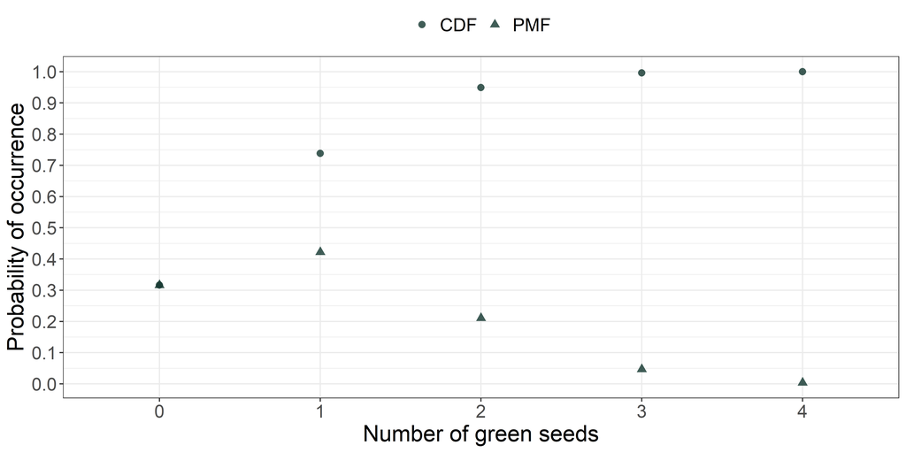

```r
library(ggplot2)
ngreen = seq(0,4,1)
aux = data.frame(ngreen, crossprob, cumuprob)
ggplot(data = aux, aes(x = factor(ngreen))) +
  geom_point(aes(y = crossprob, shape = "PMF"), size = 2.5, alpha = .8, color = "#10342d") +
  geom_point(aes(y = cumuprob, shape = "CDF"), size = 2.5, alpha = .8, color = "#10342d") +
  theme_bw() + theme(legend.position = 'top', legend.title = element_blank(),
                     text = element_text(size = 18)) +
  labs(x = "Number of green seeds", y = "Probability of occurrence") +
  scale_y_continuous(breaks = seq(0,1,0.1))
```

## Discrete random variables

- Mathematical expectation of a discrete random variable: the value of the variable around which the other values in the population tend to concentrate

$$E\left(X \right) = \mu= \sum_{i=1}^n x_i \Pr \left(x_i \right)$$

```r
expec = sum(ngreen * crossprob)
expec
```

```
[1] 1
```

- In infinite pods, the mean number of green seeds will be 1

## Discrete random variables

- The sample mean ($\bar{x}$) is the best estimator of the expected value

$$\bar{x} = \frac{1}{n}\sum_{i=1}^n f_ix_i$$

```r
set.seed(8)
sam = rbinom(n = 100000, size = 4, prob = 1/4)
tab = table(sam)
sum(ngreen*tab/sum(tab))
```

```
[1] 1.00037
```

Sample mean of values that follow a binomial distribution (our example): $E(X) = n \times p$

## Discrete random variables

- Histogram: represents frequency distributions of separate, counted values (e.g. 0, 1, 2, 3, 4)

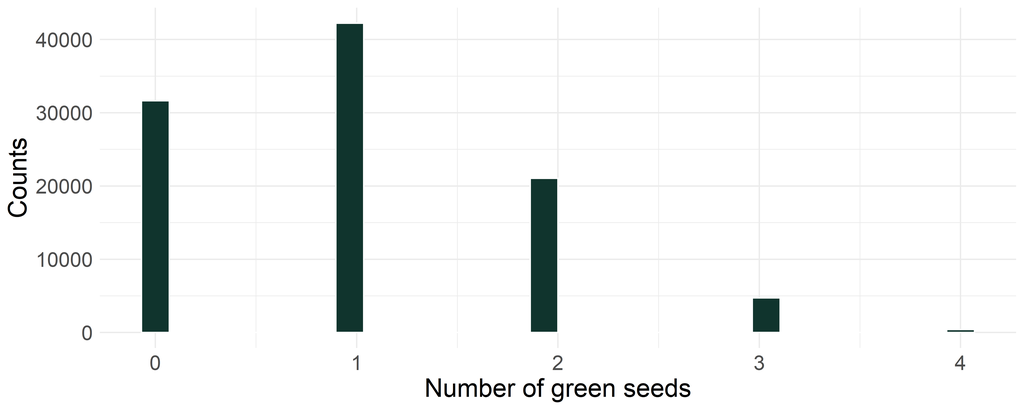

```r
ggplot(data = data.frame(sam)) +
  geom_histogram(aes(x = sam), color = "white", fill = "#10342d") +
  theme_minimal() +
  theme(text = element_text(size = 18)) +
  labs(x = "Number of green seeds", y = "Counts")
```

## Discrete Random variables

**Properties of expectation**

- $E\left( a \right) = a$
- $E\left(a X \right) = a E \left(X\right)$
- $E\left(a X \pm bY \right) = a E \left(X\right) \pm b E \left(Y\right)$
- $E\left(a X \pm b \right) = a E \left(X\right) \pm b$
- $E\left[ \left( X - a \right)^2 \right] = E\left(X^2\right) - 2aE\left( X \right) + a^2$
- $E(XY) = E(X)E(Y) \color{red}{+ Cov\left(X,Y \right)}$
- $E\left(\sum_{i=1}^n X_i\right) = \sum_{i=1}^n E\left(X_i \right)$ for $i \in \left\{1,...,n\right\}$

## Discrete random variables

- Median: the first $x_i$ value in which $F(X)\geq 0.5$

```r
median(sam)
```

```
[1] 1
```

- Mode: value of $X$ that has the highest chance of occurrence

```r
sort(tab, decreasing = TRUE)
```

```
sam
    1     0     2     3     4
42226 31626 21035  4711   402
```

Mean, median and mode are called “Measures of central tendency”

## Discrete random variables

- Variance of a discrete random variable: it measures the variability of values around the mean of the random variable

$$V(X) = \sigma^2 = E\left[ X - E(X) \right]^2 = \underbrace{E\left(X^2 \right)}_{ \sum_{i=1}^n x_i^2 \Pr \left(x_i \right) } - \left[E(X)\right]^2$$

```r
sum(ngreen^2*crossprob) - expec^2
```

```
[1] 0.75
```

- On average, the results will scatter around the mean 0.75 units<sup>2</sup>

## Discrete random variables

- Estimator for the sample variance:

$$\hat{\sigma}^2=\frac{1}{n-1}\sum_{i=1}^n \left(x_i - \bar{x} \right)^2$$

```r
var(sam)
```

```
[1] 0.7512374
```

- Standard deviation: measure of dispersion in the variable scale

$$\hat\sigma = SD(X) = \sqrt{\hat{\sigma}^2}$$

```r
sd(sam)
```

```
[1] 0.8667395
```

## Discrete random variables

- Let’s expand our experiment: Check the number of green and wrinkled seeds in a pea pod 🫛
- Bivariate discrete random variable
- Joint probability mass function $\Pr\left(X = x_i, Y = y_i \right)$

| $Y$ | $X$ $x_1$ | $X$ $x_2$ | $X$ $\dots$ | $X$ $x_n$ | $\Pr\left(Y = y_j\right)$ |  |
| --- | --- | --- | --- | --- | --- | --- |
| $y_1$ $y_2$ $\vdots$ $y_m$ | $\Pr\left(x_1 ; y_1\right)$ $\Pr\left(x_1 ; y_2\right)$ $\vdots$ $\Pr\left(x_1 ; y_m\right)$ | $\Pr\left(x_2 ; y_1\right)$ $\Pr\left(x_2 ; y_2\right)$ $\vdots$ $\Pr\left(x_2 ; y_m\right)$ | $\dots$ $\dots$ $\ddots$ $\dots$ | $\Pr\left(x_n ; y_1\right)$ $\Pr\left(x_n ; y_2\right)$ $\vdots$ $\Pr\left(x_n ; y_m\right)$ |  | $\Pr\left(y_1\right)$ $\Pr\left(y_2\right)$ $\vdots$ $\Pr\left(y_m\right)$ |
| $\Pr\left(X=x_i\right)$ | $\Pr\left(x_1\right)$ | $\Pr\left(x_2\right)$ | $\dots$ | $\Pr\left(x_n\right)$ | $1$ |  |

## Discrete random variables

- There is independence if $\Pr\left(x_i;y_i\right) = \Pr\left(x_i\right) \times \Pr\left(y_i\right)$
- If this condition is not met, then there is a covariance between traits
  - Measures the dispersion of a given variable in relation to another

$$Cov\left(X,Y\right) = \sigma_{XY} = E\left\{\left[X-E(X) \right] \left[Y-E(Y) \right]\right\}$$

$$Cov\left(X,Y\right) = \sigma_{XY} = \underbrace{E(XY)}_{\sum_{i=1}^n\sum_{j=1}^m x_iy_j \Pr\left(x_i;y_j\right)} - \left[E(X) E(Y)\right]$$

## Discrete random variables

- Estimator for the sample covariance:

$$\hat{\sigma}_{xy} = \frac{\sum_{i=1}^{n} (x_i - \bar{x})(y_i - \bar{y})}{n - 1}$$

```r
set.seed(99)
sam2 = rbinom(n = 100000, size = 4, prob = 1/4)
tab2 = table(sam2)
cov(sam, sam2)
```

```
[1] -0.001539553
```

## Discrete random variables

- Scatter plot: relationship between two random variables

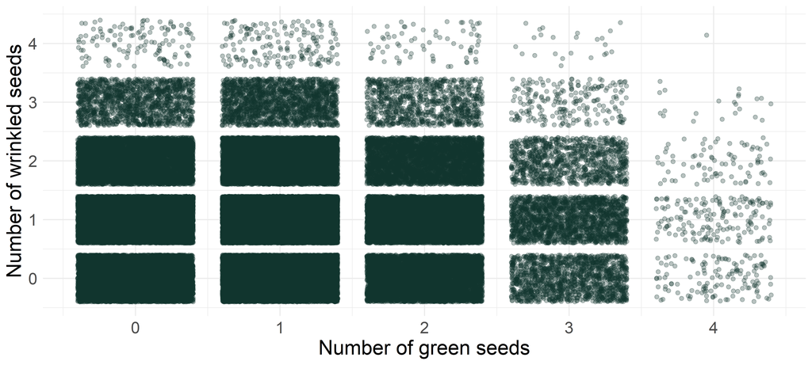

```r
ggplot(data = data.frame(sam, sam2), aes(x = sam, y = sam2)) +
  geom_jitter(alpha = .3, color = "#10342d") +
  labs(x = "Number of green seeds", y = "Number of wrinkled seeds") +
  theme_minimal() + theme(text = element_text(size = 18))
```

## Discrete random variables

- Usually, variables come in different scales
  - Hard to interpret values, only signs are informative
- Correlation: dimensionless

$$\rho = \frac{Cov(X,Y)}{\sqrt{Var(X) Var(Y)}}$$

$$-1 \leq \rho \leq1$$

```r
cor(sam, sam2)
```

```
[1] -0.002049549
```

## Continuous random variables

- Assumes infinite values within a given range

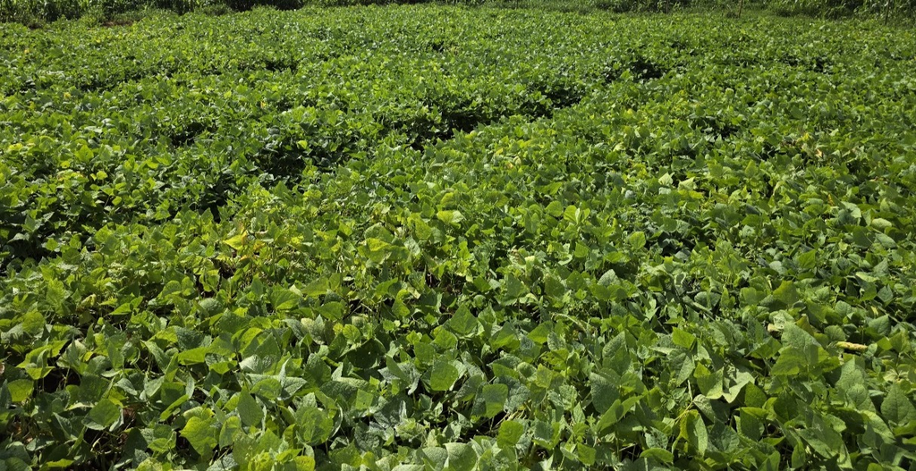

- Chance experiment: common-bean yield in a field trial

$$X = \{x \in \mathbb{R} \mid x \ge 0\}$$

## Continuous random variables

- Probability density function: gives the probability that a continuous random variable falling within a specific range of values
- A PDF must adhere to the following conditions:

$$f(x) = \begin{cases}
0 & X<a \\
f(x) & a \leq X \leq b \\
0 & X>b
\end{cases}$$

$$\int_a^bf(x)dx = 1$$

## Continuous random variables

$$f(x) = \frac{1}{\sqrt{2 \pi \sigma^2}}\exp\left[-\frac{1}{2} \left(\frac{x-\mu}{\sigma}\right)^2\right]$$

[figure not shown]

[WikiMedias](https://en.wikipedia.org/wiki/Normal_distribution)

## Continuous random variables

- Probability of X assuming a value between a certain interval: area under the curve between this interval

$$\Pr\left(c \leq X \leq d \right) = \int_c^d f(x)dx$$

[figure not shown]

[Ainali](https://en.wikipedia.org/wiki/Normal_distribution)

## Continuous random variables

- Cumulative distribution function: same idea as CDF for discrete random variables

$$F(x) = \Pr\left(X \leq x \right)$$

- Area under the curve up to a given value

$$F(x) = \Pr\left(X \leq x \right) = \begin{cases}
0 & X<a \\
\int_a^x f(x)d(x) & a \leq X \leq x \mbox{ with } x<b \\
1 & X \geq b
\end{cases}$$

## Continuous random variables

- Normal distribution CDF:

[figure not shown]

[Inductiveload](https://en.wikipedia.org/wiki/Cumulative_distribution_function)

## Continuous random variables

- Expectation of a continuous random variable: point that represents the center of the mass

$$E(X) = \mu = \int_a^b x \times f(x) dx$$

- Sample (arithmetic) mean for continuous random variables (Normal FDP):

$$\bar{x} = \frac{1}{n} \sum_{i=1}^n x_i$$

## Continuous random variables

- Generation of random numbers using the Normal Distribution:

```r
set.seed(8)
sam = rnorm(n = 1000, mean = 1000, sd = 100)
sam[1:10]
```

```
 [1]  991.5414 1084.0400  953.6517  944.9165 1073.6040  989.2119  982.9711
 [8]  891.1668  698.8948  940.6826
```

```r
mean(sam)
```

```
[1] 995.8738
```

## Continuous random variables

- Histogram (continuous variables): groups values into adjacent, equal-sized intervals (bins)

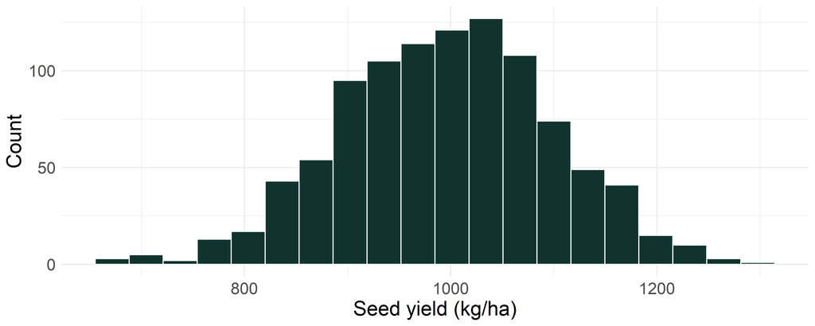

```r
ggplot(data = data.frame(sam)) +
  geom_histogram(aes(x = sam), bins = 20, color = 'white', fill = "#10342d") +
  labs(x = "Seed yield (kg/ha)", y = "Count") +
  theme_minimal() + theme(text = element_text(size = 18))
```

## Continuous random variables

- Density plots: similar representation than histograms, but **without discretization**
  - *y*-axis: density $\to$ relative frequency using Kernel Density Estimation

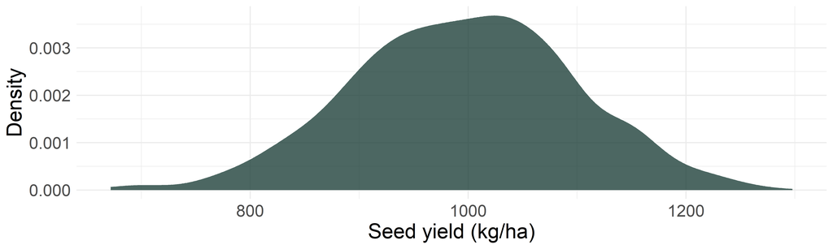

```r
ggplot(data = data.frame(sam)) +
  geom_density(aes(x = sam),color = 'white', fill = '#10342d', alpha = .75) +
  labs(x = "Seed yield (kg/ha)", y = "Density") +
  theme_minimal() + theme(text = element_text(size = 18))
```

## Continuous random variables

- Median: a value that divides the distribution exactly in half

```r
median(sam)
```

```
[1] 997.1516
```

- Mode: the value $x$ that maximizes its PDF (the peak of the distribution)

```r
samdens = density(sam)
samdens$x[which.max(samdens$y)]
```

```
[1] 1024.459
```

## Continuous random variables

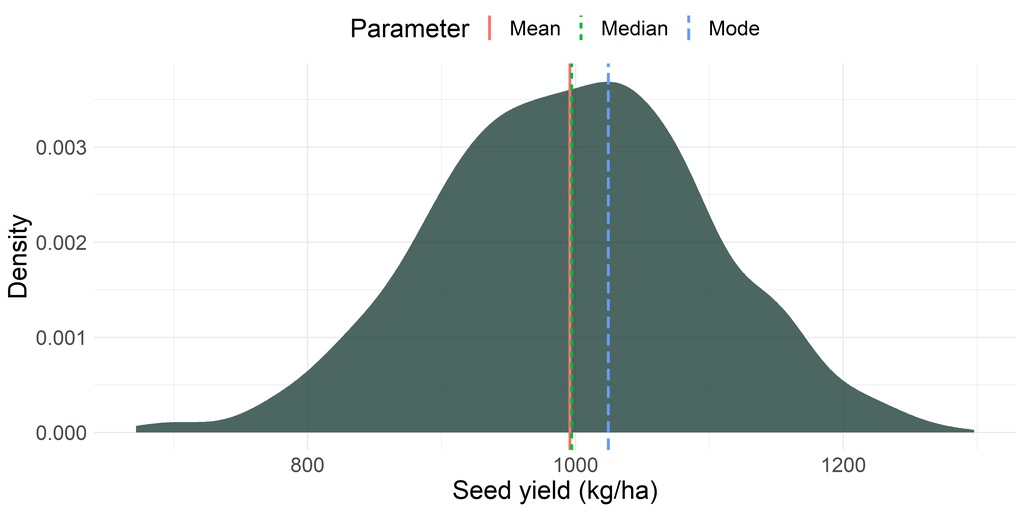

```r
ggplot(data = data.frame(sam)) +
  geom_density(aes(x = sam),color = 'white', fill = '#10342d', alpha = .75)  +
  theme_minimal() + theme(text = element_text(size = 18), legend.position = 'top') +
  geom_vline(aes(xintercept = mean(sam), linetype = "Mean", color = "Mean"), linewidth = 1)+
  geom_vline(aes(xintercept = median(sam), linetype = "Median", color = "Median"), linewidth = 1)+
  geom_vline(aes(xintercept = samdens$x[which.max(samdens$y)], linetype = "Mode", color = "Mode"), linewidth = 1)+
  labs(x = "Seed yield (kg/ha)", y = "Density", linetype = "Parameter", colour = "Parameter")
```

## Continuous random variables

- Variance [in (kg/ha)<sup>2</sup>]

```r
var(sam)
```

```
[1] 10447.73
```

- Standard deviation (in kg/ha)

```r
sd(sam)
```

```
[1] 102.2141
```

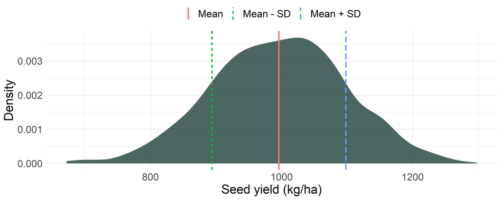

```r
ggplot(data = data.frame(sam)) +
  geom_density(aes(x = sam),color = 'white', fill = '#10342d', alpha = .75)  +
  theme_minimal() + theme(text = element_text(size = 18), legend.position = 'top',
                          legend.title = element_blank()) +
  geom_vline(aes(xintercept = mean(sam), linetype = "Mean", color = "Mean"), linewidth = 1)+
  labs(x = "Seed yield (kg/ha)", y = "Density", linetype = "Parameter", colour = "Parameter") +
  geom_vline(aes(xintercept = mean(sam) + sd(sam), linetype = "Mean + SD", color = "Mean + SD"), linewidth = 1) +
  geom_vline(aes(xintercept = mean(sam) - sd(sam), linetype = "Mean - SD", color = "Mean - SD"), linewidth = 1)
```

## Continuous random variables

- Box plots: visualize the distribution of continuous data using its minimum, first quartile, median, third quartile, and maximum

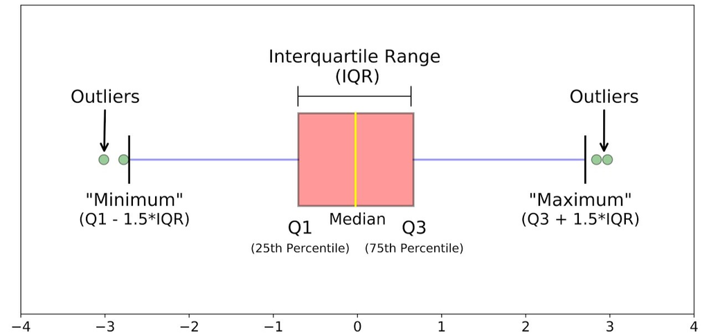

[Michael Galarnyk](https://www.kdnuggets.com/2019/11/understanding-boxplots.html)

## Continuous random variables

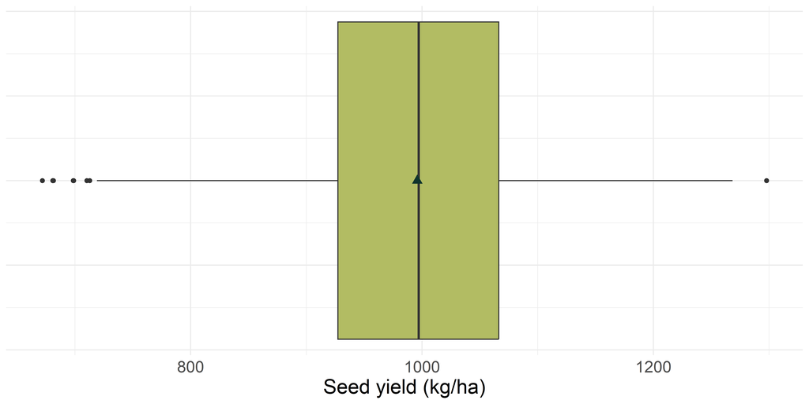

```r
ggplot(data = data.frame(sam)) +
  geom_boxplot(aes(x = sam), fill = "#b2bc63") +
  annotate(geom = 'point', x = mean(sam), y = 0, shape = 17, color = "#10342d", size = 3)+
  theme_minimal() + theme(axis.text.y = element_blank(), text = element_text(size = 18)) +

  labs(x = "Seed yield (kg/ha)")
```

## Continuous random variables

- Covariance and correlation

```r
rho = .75
s21 = 1.5
s22 = 4
cov12 = rho*sqrt(s21*s22)
Sigma = matrix(c(
  s21, cov12,
  cov12, s22
), nrow = 2)

set.seed(16735969)
dat = MASS::mvrnorm(n = 1000, mu = c(5.5, 25), Sigma = Sigma)
colnames(dat) = c("hgw", "npods")
```

- Covariance in g $\times$ units

```r
cov(dat[,1], dat[,2])
```

```
[1] 2.093912
```

- Correlation is dimensionless

```r
cor(dat[,1], dat[,2])
```

```
[1] 0.7679006
```

## Continuous random variables

- Scatter plot: relationship between traits

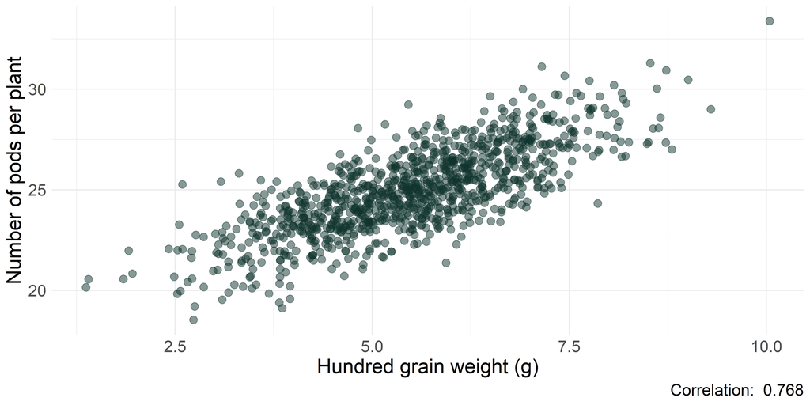

## Central Limit Theorem

Data that are influenced by many small and unrelated random effects are approximately normally distributed. In other words, as the sample size increases, the sampling distribution of the means (or sums) of samples taken from any distribution approaches the normal distribution.

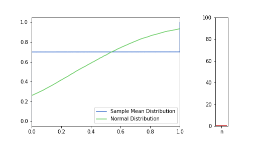

[Mate Pocs/Medium](https://medium.com/analytics-vidhya/central-limit-theorem-recommended-visualisations-c22307c132a8)

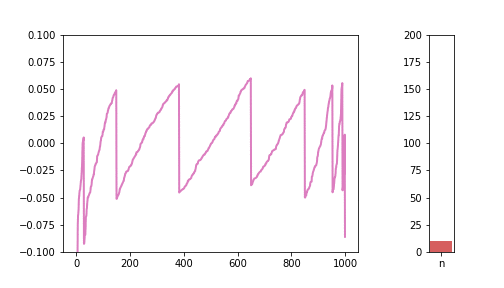

[Mate Pocs/Medium](https://medium.com/analytics-vidhya/central-limit-theorem-recommended-visualisations-c22307c132a8)

## Central Limit Theorem

- Let $X_1, ..., X_n$ be a sequence of $n$ i.i.d. random variables, with $E\left(X_i\right) = \mu$ and $V\left(X_i\right) = \sigma^2$
- Let $Y = X_1+...+X_n$

$$E(Y) = E\left(X_1\right) + ... + E\left(X_n\right) = n\times E(X) = n\mu$$

$$V(Y) = V\left(X_1\right) + ... + V\left(X_n\right) = n \times V(X) = n \sigma^2$$

- Let $Z$ be a standardized version of $Y$:

$$\begin{gather*}
Z = \frac{Y-n\mu}{\sqrt{n\sigma^2}} \\
Z \sim \mathcal{N}\left(0, 1\right) \mbox{ when } n \to \infty
\end{gather*}$$

## Central Limit Theorem

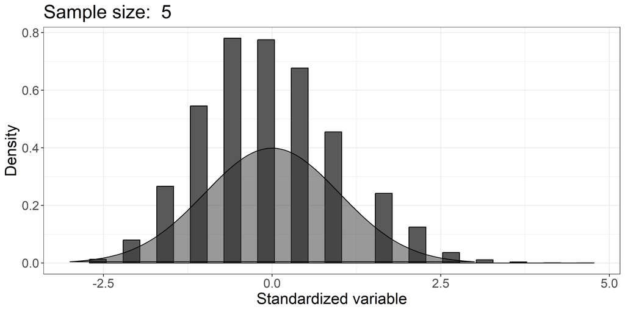

```r
E_x = sum(ngreen * crossprob)
V_x = sum(ngreen^2*crossprob) - expec^2
n = 5
iter = 10000
zn = NULL
for (i in 1:iter){
  y = sum(rbinom(n = n, size = 4, prob = 1/4))
  E_y = n * E_x
  V_y = n * V_x
  zn[i] = (y - E_y) / sqrt(V_y)
}

ggplot() +
  geom_histogram(aes(x = zn, y = after_stat(density)), color = 'black') +
  stat_function(fun = function(x) dnorm(x, mean = 0, sd = 1), xlim = c(-3,3),
                geom = "polygon", alpha = .5, color = 'black') +
  theme_bw() +
  theme(text = element_text(size = 18)) +
  labs(x = "Standardized variable", y = "Density", title = paste("Sample size: ", n))
```

## Central Limit Theorem

- Now let $Y = \frac{\sum X_i}{n}$

$$E(Y) = E\left(\frac{X_1}{n}\right)+\dots +E\left(\frac{X_i}{n}\right)= n\times\frac{1}{n}E(X) = \mu$$

$$V(Y) = V\left(\frac{X_1}{n}\right)+\dots +V\left(\frac{X_i}{n}\right) = \frac{1}{n^2} \times n \times V(X) = \frac{\sigma^2}{n}$$

$$Z=\frac{Y-\mu}{\sqrt\frac{\sigma^2}{n}}$$

## Central Limit Theorem

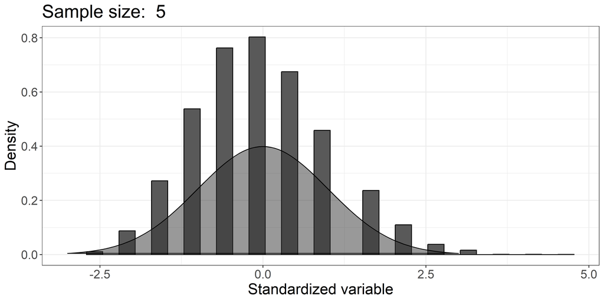

```r
n = 5
zn = NULL
for (i in 1:iter){
  y = mean(rbinom(n = n, size = 4, prob = 1/4))
  E_y = E_x
  V_y = V_x/n
  zn[i] = (y - E_y) / sqrt(V_y)
}

ggplot() +
  geom_histogram(aes(x = zn, y = after_stat(density)), color = 'black') +
  stat_function(fun = function(x) dnorm(x, mean = 0, sd = 1), xlim = c(-3,3),
                geom = "polygon", alpha = .5, color = 'black') +
  theme_bw() +
  theme(text = element_text(size = 18)) +
  labs(x = "Standardized variable", y = "Density", title = paste("Sample size: ", n))
```

## Central Limit Theorem

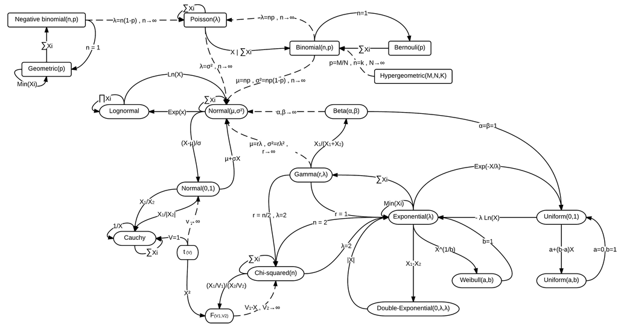

[Leemis & McQueston (2008)](https://www.kdnuggets.com/2019/11/understanding-boxplots.html)

## Your turn

Using your USP number as seed, simulate **phenotypic values** (don’t forget, $P = G + E$) using the normal distribution (`rnorm`). Then, compute the mean and the variance of $P$, $G$ and $E$, and build a histogram, a density plot, a box plot and a scatter plot depicting the relationship between $P$ and $G$. Do it for three different sample sizes: 10, 100 and 1000.

# Exploratory Data Analysis (EDA)

## Exploratory Data Analysis

- First, let’s load the dataset

```r
dat = read.csv("https://raw.githubusercontent.com/mauricioaraujj/Pan_African_Trials_Network/refs/heads/main/data/data.csv",
               sep = ';')
dim(dat)
```

```
[1] 27638    42
```

```r
dat_sub = subset(dat, env == "E007")
dim(dat_sub)
```

```
[1] 60 42
```

```r
head(dat_sub)
```

```
    COUNTRY YEAR  env  gen  loc SEASON rep check PL_EMERG_COUNT PL_EMERG_PCT
382   Kenya 2016 E007 G070 L001      2   1     0              0            0
383   Kenya 2016 E007 G037 L001      2   1     0              0            0
384   Kenya 2016 E007 G039 L001      2   1     1              0            0
385   Kenya 2016 E007 G035 L001      2   1     0              0            0
386   Kenya 2016 E007 G007 L001      2   1     0              0            0
387   Kenya 2016 E007 G040 L001      2   1     0              0            0
    FLW_DAYS FLW_CL PUB_CL NDM LOD PODDING_MAT Pod_Shattering PH_R8 W100G   GY
382        0   <NA>   <NA> 175   0           0              0 68.00     0 1000
383        0   <NA>   <NA> 113   0           0              0 40.00     0 1300
384        0   <NA>   <NA> 125   0           0              0 50.50     0 1700
385        0   <NA>   <NA> 113   0           0              0 48.75     0 2250
386        0   <NA>   <NA> 116   0           0              0 41.25     0 1450
387        0   <NA>   <NA> 132   0           0              0 45.25     0  800
    R6_BB_Sev R6_BP_Sev R6_BS_Sev R6_BTS_Sev R6_CLB_Sev R6_DM_Sev R6_MLS_Sev
```

[output cut: 27 more lines]

## Exploratory Data Analysis

```r
str(dat_sub)
```

```
'data.frame':   60 obs. of  42 variables:
 $ COUNTRY       : chr  "Kenya" "Kenya" "Kenya" "Kenya" ...
 $ YEAR          : int  2016 2016 2016 2016 2016 2016 2016 2016 2016 2016 ...
 $ env           : chr  "E007" "E007" "E007" "E007" ...
 $ gen           : chr  "G070" "G037" "G039" "G035" ...
 $ loc           : chr  "L001" "L001" "L001" "L001" ...
 $ SEASON        : int  2 2 2 2 2 2 2 2 2 2 ...
 $ rep           : int  1 1 1 1 1 1 1 1 1 1 ...
 $ check         : int  0 0 1 0 0 0 0 0 0 0 ...
 $ PL_EMERG_COUNT: num  0 0 0 0 0 0 0 0 0 0 ...
 $ PL_EMERG_PCT  : num  0 0 0 0 0 0 0 0 0 0 ...
 $ FLW_DAYS      : int  0 0 0 0 0 0 0 0 0 0 ...
 $ FLW_CL        : chr  NA NA NA NA ...
 $ PUB_CL        : chr  NA NA NA NA ...
 $ NDM           : int  175 113 125 113 116 132 175 132 116 175 ...
```

[output cut: 28 more lines]

```r
table(dat_sub$rep, dat_sub$gen)
```

```
    G007 G010 G012 G019 G035 G036 G037 G039 G040 G070 G126 G129 G136 G138 G141
  1    1    1    1    1    1    1    1    1    1    1    1    1    1    1    1
  2    1    1    1    1    1    1    1    1    1    1    1    1    1    1    1
  3    1    1    1    1    1    1    1    1    1    1    1    1    1    1    1

    G147 G148 G164 G166 G177
  1    1    1    1    1    1
  2    1    1    1    1    1
  3    1    1    1    1    1
```

## Exploratory Data Analysis

```r
summary(dat_sub$GY)
```

```
   Min. 1st Qu.  Median    Mean 3rd Qu.    Max.    NA's
    450    1150    1575    1634    2138    3500       2
```

```r
tapply(dat_sub$GY, dat_sub$gen, function(x) mean(x, na.rm = TRUE))
```

```
     G007      G010      G012      G019      G035      G036      G037      G039
1550.0000 2700.0000 2000.0000 2016.6667 2300.0000 1216.6667 1050.0000 1650.0000
     G040      G070      G126      G129      G136      G138      G141      G147
1166.6667 2100.0000  466.6667 1250.0000 1550.0000 1900.0000 1783.3333 1000.0000
     G148      G164      G166      G177
1233.3333 1750.0000 1733.3333 1833.3333
```

```r
tapply(dat_sub$GY, dat_sub$gen, function(x) sd(x, na.rm = TRUE))
```

```
      G007       G010       G012       G019       G035       G036       G037
 132.28757  100.00000  300.00000 1102.64833  327.87193  256.58007  229.12878
      G039       G040       G070       G126       G129       G136       G138
 327.87193  375.27767 1276.71453   28.86751  482.18254  476.96960  500.00000
      G141       G147       G148       G164       G166       G177
 368.55574         NA  500.83264  476.96960  629.15287  637.05050
```

## Exploratory Data Analysis

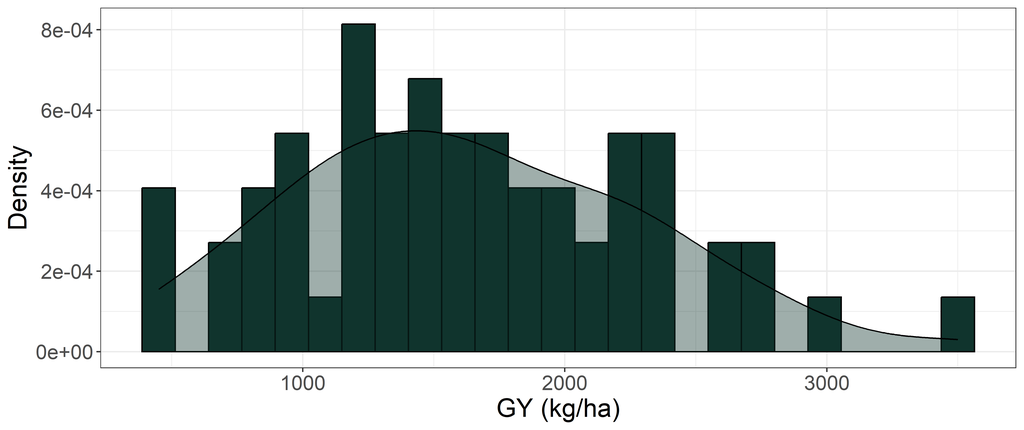

```r
ggplot(data = dat_sub, aes(x = GY)) +
  geom_histogram(bins = 25, color = 'black', fill="#10342d",
                 aes(y=after_stat(density))) +
  geom_density(fill = "#10342d", alpha = .4, color = "black")+
  theme_bw() +
  theme(text = element_text(size = 18)) +
  labs(y = "Density", x = "GY (kg/ha)")
```

## Exploratory Data Analysis

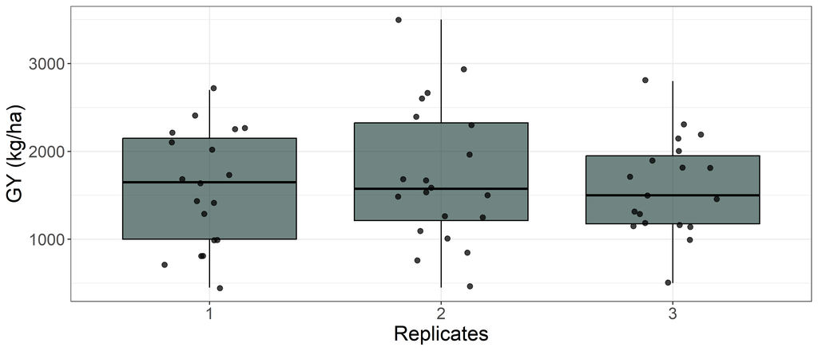

```r
ggplot(data = dat_sub, aes(x = as.factor(rep), y = GY)) +
  geom_boxplot(fill = "#10342d", color = "black", alpha = .6) +
  geom_jitter(width = .2, size = 2, alpha = .75, color = "black") +
  theme_bw() +
  theme(text = element_text(size = 18)) +
  labs(x = "Replicates", y = "GY (kg/ha)")
```

## Exploratory Data Analysis

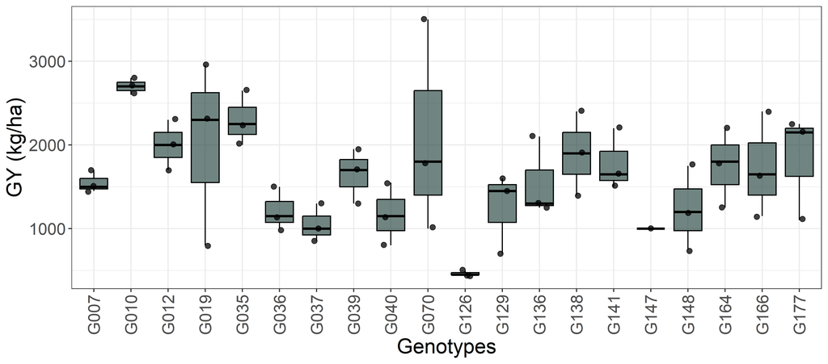

```r
ggplot(data = dat_sub, aes(x = as.factor(gen), y = GY)) +
  geom_boxplot(fill = "#10342d", color = "black", alpha = .6) +
  geom_jitter(width = .2, size = 2, alpha = .75, color = "black") +
  theme_bw() +
  theme(text = element_text(size = 18),
        axis.text.x = element_text(angle = 90, vjust = .5, hjust = 1)) +
  labs(x = "Genotypes", y = "GY (kg/ha)")
```

## Exploratory Data Analysis

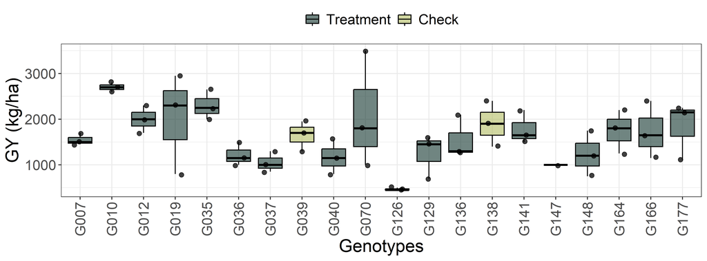

```r
ggplot(data = dat_sub, aes(x = as.factor(gen), y = GY)) +
  geom_boxplot(aes(fill = as.factor(check)), color = "black", alpha = .6) +
  geom_jitter(width = .2, size = 2, alpha = .75, color = "black") +
  theme_bw() +
  theme(text = element_text(size = 18), legend.position = 'top', legend.title = element_blank(),
        axis.text.x = element_text(angle = 90, vjust = .5, hjust = 1)) +
  scale_fill_manual(labels = c("0" = "Treatment", "1" = "Check"),
                    values = c("0" = "#10342d", "1" = "#b2bc63"))+
  labs(x = "Genotypes", y = "GY (kg/ha)")
```

## Exploratory Data Analysis

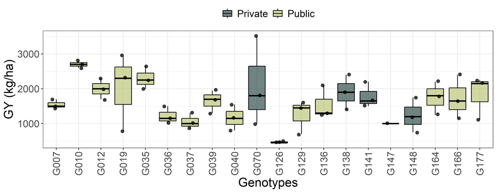

```r
ggplot(data = dat_sub, aes(x = as.factor(gen), y = GY)) +
  geom_boxplot(aes(fill = as.factor(COMPANY)), color = "black", alpha = .6) +
  geom_jitter(width = .2, size = 2, alpha = .75, color = "black") +
  theme_bw() +
  theme(text = element_text(size = 18), legend.position = 'top',
        legend.title = element_blank(),
        axis.text.x = element_text(angle = 90, vjust = .5, hjust = 1)) +
  scale_fill_manual(values = c("#10342d", "#b2bc63"))+
  labs(x = "Genotypes", y = "GY (kg/ha)")
```

## Exploratory Data Analysis

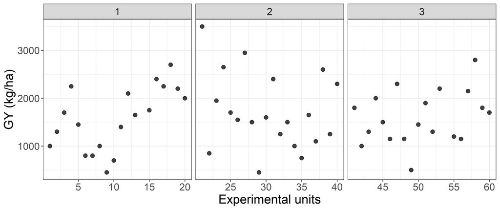

```r
dat_sub$ord = 1:nrow(dat_sub)

ggplot(data = dat_sub, aes(x = ord, y = GY)) +
  geom_point(size = 2.5, alpha = .75, color = "black") +
  facet_wrap(.~rep, scales = 'free_x')+
  theme_bw() +
  theme(text = element_text(size = 18)) +
  labs(x = "Experimental units", y = "GY (kg/ha)")
```

## Exploratory Data Analysis

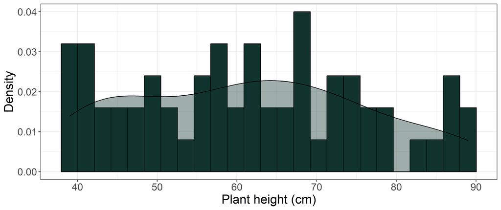

```r
ggplot(data = dat_sub, aes(x = PH_R8)) +
  geom_histogram(bins = 25, color = 'black', fill="#10342d",
                 aes(y=after_stat(density))) +
  geom_density(fill = "#10342d", alpha = .4, color = "black")+
  theme_bw() +
  theme(text = element_text(size = 18)) +
  labs(y = "Density", x = "Plant height (cm)")
```

## Exploratory Data Analysis

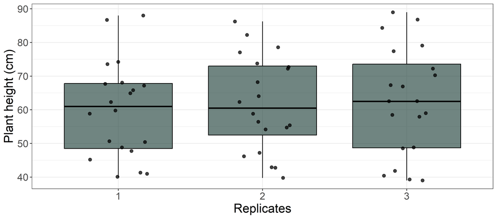

```r
ggplot(data = dat_sub, aes(x = as.factor(rep), y = PH_R8)) +
  geom_boxplot(fill = "#10342d", color = "black", alpha = .6) +
  geom_jitter(width = .2, size = 2, alpha = .75, color = "black") +
  theme_bw() +
  theme(text = element_text(size = 18)) +
  labs(x = "Replicates", y = "Plant height (cm)")
```

## Exploratory Data Analysis

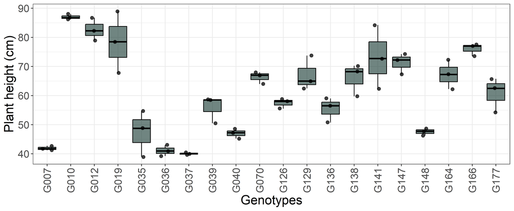

```r
ggplot(data = dat_sub, aes(x = as.factor(gen), y = PH_R8)) +
  geom_boxplot(fill = "#10342d", color = "black", alpha = .6) +
  geom_jitter(width = .2, size = 2, alpha = .75, color = "black") +
  theme_bw() +
  theme(text = element_text(size = 18),
        axis.text.x = element_text(angle = 90, vjust = .5, hjust = 1)) +
  labs(x = "Genotypes", y = "Plant height (cm)")
```

## Exploratory Data Analysis

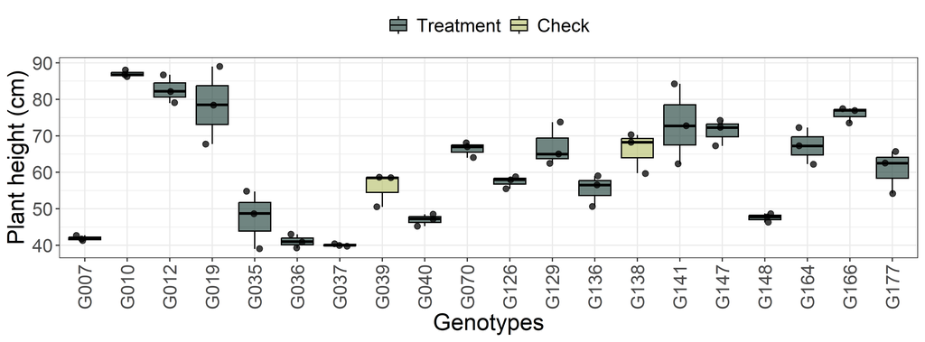

```r
ggplot(data = dat_sub, aes(x = as.factor(gen), y = PH_R8)) +
  geom_boxplot(aes(fill = as.factor(check)), color = "black", alpha = .6) +
  geom_jitter(width = .2, size = 2, alpha = .75, color = "black") +
  theme_bw() +
  theme(text = element_text(size = 18), legend.position = 'top',
        legend.title = element_blank(),
        axis.text.x = element_text(angle = 90, vjust = .5, hjust = 1)) +
  scale_fill_manual(labels = c("0" = "Treatment", "1" = "Check"),
                    values = c("0" = "#10342d", "1" = "#b2bc63"))+
  labs(x = "Genotypes", y = "Plant height (cm)")
```

## Exploratory Data Analysis

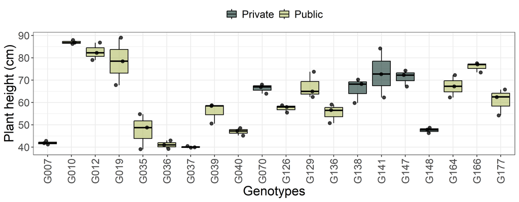

```r
ggplot(data = dat_sub, aes(x = as.factor(gen), y = PH_R8)) +
  geom_boxplot(aes(fill = as.factor(COMPANY)), color = "black", alpha = .6) +
  geom_jitter(width = .2, size = 2, alpha = .75, color = "black") +
  theme_bw() +
  theme(text = element_text(size = 18), legend.position = 'top',
        legend.title = element_blank(),
        axis.text.x = element_text(angle = 90, vjust = .5, hjust = 1)) +
  scale_fill_manual(values = c("#10342d", "#b2bc63"))+
  labs(x = "Genotypes", y = "Plant height (cm)")
```

## Exploratory Data Analysis

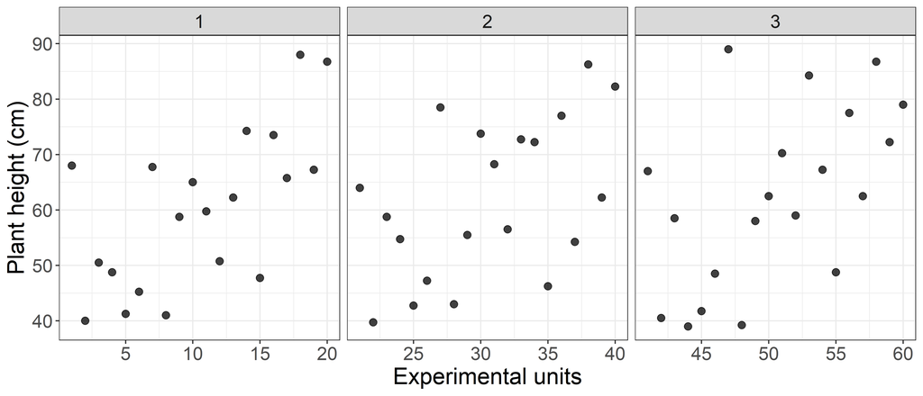

```r
ggplot(data = dat_sub, aes(x = ord, y = PH_R8)) +
  geom_point(size = 2.5, alpha = .75, color = "black") +
  facet_wrap(.~rep, scales = 'free_x')+
  theme_bw() +
  theme(text = element_text(size = 18)) +
  labs(x = "Experimental units", y = "Plant height (cm)")
```